# GSE47552 Microarray Analysis

Popoola Abdulgafar

2026-09-30

Abstract

# GSE47552 Microarray Analysis

## 1. Introduction

This project analyzes the GSE47552 gene-expression dataset to identify genes that are differentially expressed between Multiple Myeloma (MM) plasma cells and Normal Plasma Cells (NPC).

The analysis includes differential expression analysis, visualization of expression patterns, principal component analysis (PCA), heatmap analysis, and functional enrichment using Gene Ontology (GO) and KEGG pathways.

## 2. Dataset

The dataset was obtained from the Gene Expression Omnibus (GEO) using the GEOquery package.

The analysis focuses on the comparison between Multiple Myeloma (MM) plasma cells and Normal Plasma Cells (NPC).

## 3. Load packages and data

```r
options(timeout = 600)
library(GEOquery)
library(limma)
```

```r
library(ggplot2)
library(pheatmap)
library(clusterProfiler)
library(org.Hs.eg.db)
gse <- getGEO("GSE47552", GSEMatrix = TRUE)
```

```
## Found 1 file(s)
```

```
## GSE47552_series_matrix.txt.gz
```

```r
expr <- exprs(gse[[1]])
pheno <- pData(gse[[1]])

dim(expr)
```

```
## [1] 33297    99
```

## 4. Sample metadata

The sample metadata were examined to identify the biological groups represented in the dataset.

```r
metadata <- data.frame(
  Sample = rownames(pheno),
  Group = pheno$`cell type:ch1`
)

table(metadata$Group)
```

```
##
## Monoclonal Gammopathy of Undetermined Significance (MGUS) plasma cells
##                                                                     20
##                                     Multiple Myeloma (MM) plasma cells
##                                                                     41
##                                               Normal Plama Cells (NPC)
##                                                                      5
##                         Smoldering Multiple Myeloma (SMM) plasma cells
##                                                                     33
```

```r
head(metadata)
```

```
##       Sample
## 1 GSM1152289
## 2 GSM1152290
## 3 GSM1152291
## 4 GSM1152292
## 5 GSM1152293
## 6 GSM1152294
##                                                                    Group
## 1 Monoclonal Gammopathy of Undetermined Significance (MGUS) plasma cells
## 2 Monoclonal Gammopathy of Undetermined Significance (MGUS) plasma cells
## 3 Monoclonal Gammopathy of Undetermined Significance (MGUS) plasma cells
## 4 Monoclonal Gammopathy of Undetermined Significance (MGUS) plasma cells
## 5 Monoclonal Gammopathy of Undetermined Significance (MGUS) plasma cells
## 6 Monoclonal Gammopathy of Undetermined Significance (MGUS) plasma cells
```

## 5. Differential expression: MM versus NPC

For the differential-expression analysis, Multiple Myeloma (MM) plasma cells were compared with Normal Plasma Cells (NPC). The analysis was performed using the `limma` package, which is appropriate for microarray expression data.

```r
keep <- metadata$Group %in% c(
  "Multiple Myeloma (MM) plasma cells",
  "Normal Plama Cells (NPC)"
)

expr_sub <- expr[, keep]
meta_sub <- metadata[keep, ]

meta_sub$Group <- factor(
  meta_sub$Group,
  levels = c(
    "Normal Plama Cells (NPC)",
    "Multiple Myeloma (MM) plasma cells"
  )
)

design <- model.matrix(~0 + meta_sub$Group)
colnames(design) <- c("NPC", "MM")

fit <- lmFit(expr_sub, design)

contrast.matrix <- makeContrasts(
  MMvsNPC = MM - NPC,
  levels = design
)

fit2 <- contrasts.fit(fit, contrast.matrix)
fit2 <- eBayes(fit2)

results <- topTable(
  fit2,
  coef = "MMvsNPC",
  number = Inf,
  adjust.method = "BH"
)

head(results)
```

```
##             logFC  AveExpr         t      P.Value    adj.P.Val        B
## 7986563 -4.422150 3.810648 -15.77928 2.124630e-20 7.074379e-16 35.18565
## 8071597 -3.421432 6.971038 -13.92170 2.756570e-18 4.497437e-14 30.75070
## 7969916 -1.143437 3.555326 -13.78095 4.052110e-18 4.497437e-14 30.39584
## 8071655 -3.271381 7.474088 -13.41542 1.114649e-17 9.278617e-14 29.46140
## 8117079 -2.676221 3.959627 -12.47889 1.607552e-16 1.070533e-12 26.98133
## 7980523 -2.188362 7.263023 -12.37836 2.154976e-16 1.195904e-12 26.70769
```

## 6. Volcano plot

A volcano plot was used to visualize the relationship between statistical significance and magnitude of differential expression. The x-axis represents log fold change, while the y-axis represents the negative log10-transformed P-value.

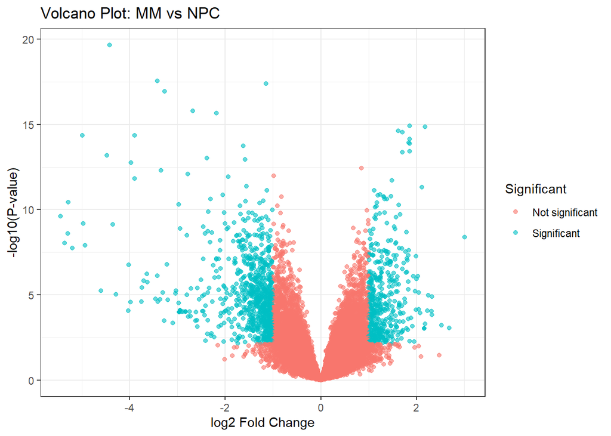

```r
results$Significant <- ifelse(
  results$adj.P.Val < 0.05 & abs(results$logFC) > 1,
  "Significant",
  "Not significant"
)

volcano_plot <- ggplot(results, aes(x = logFC, y = -log10(P.Value))) +
  geom_point(aes(color = Significant), alpha = 0.6) +
  theme_bw() +
  labs(
    title = "Volcano Plot: MM vs NPC",
    x = "log2 Fold Change",
    y = "-log10(P-value)"
  )

volcano_plot
```

```r
ggsave(
  "results/Volcano_MM_vs_NPC.png",
  plot = volcano_plot,
  width = 8,
  height = 6,
  dpi = 300,
  create.dir = TRUE
)
```

## 7. Principal Component Analysis (PCA)

Principal component analysis was used to visualize the overall structure of the gene-expression data and assess whether MM and NPC samples show separation based on their global expression profiles.

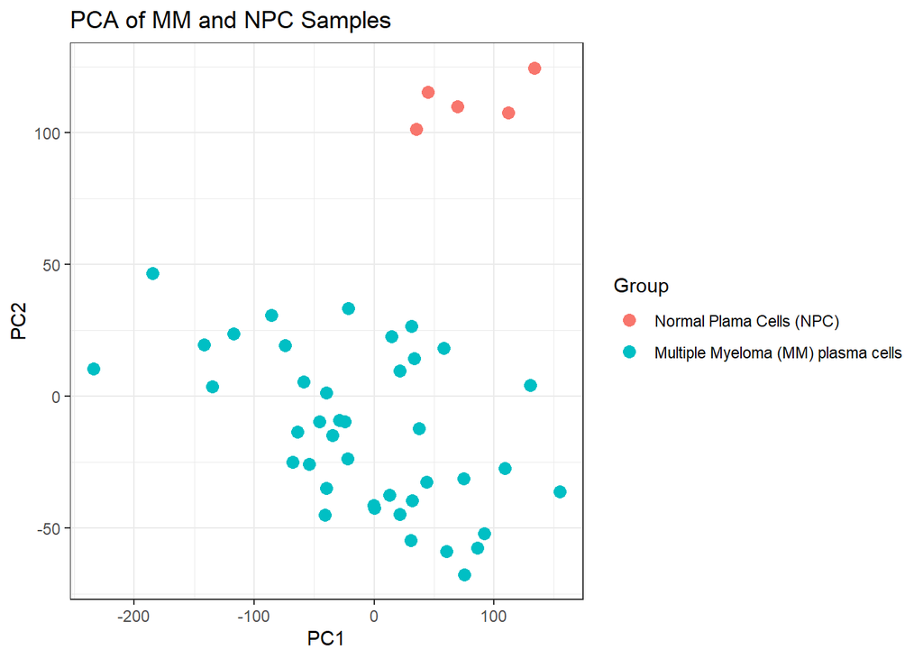

```r
pca <- prcomp(t(expr_sub), scale. = TRUE)

pca_data <- data.frame(
  PC1 = pca$x[, 1],
  PC2 = pca$x[, 2],
  Group = meta_sub$Group
)

pca_plot <- ggplot(pca_data, aes(x = PC1, y = PC2, color = Group)) +
  geom_point(size = 3) +
  theme_bw() +
  labs(
    title = "PCA of MM and NPC Samples",
    x = "PC1",
    y = "PC2"
  )

pca_plot
```

```r
ggsave(
  "results/PCA_MM_vs_NPC.png",
  plot = pca_plot,
  width = 8,
  height = 6,
  dpi = 300,
  create.dir = TRUE
)
```

## 8. Heatmap of differentially expressed genes

A heatmap was used to visualize the expression patterns of selected differentially expressed genes across the MM and NPC samples.

```r
sig_genes <- results[
  results$adj.P.Val < 0.05 & abs(results$logFC) > 1,
]

top_genes <- rownames(sig_genes)[1:min(50, nrow(sig_genes))]

heatmap_data <- expr_sub[top_genes, ]

annotation_col <- data.frame(
  Group = meta_sub$Group
)

rownames(annotation_col) <- colnames(heatmap_data)

print(dim(heatmap_data))
```

```
## [1] 50 46
```

```r
print(range(heatmap_data, na.rm = TRUE))
```

```
## [1]  2.14511 13.26136
```

```r
print(sum(is.na(heatmap_data)))
```

```
## [1] 0
```

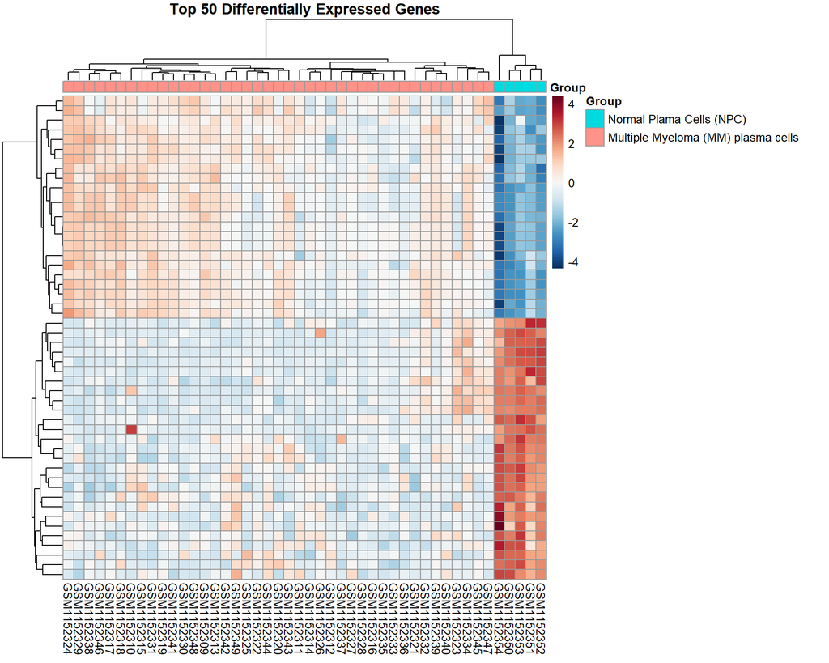

```r
library(RColorBrewer)
library(pheatmap)

png(
  "results/improved_heatmap.png",
  width = 3000,
  height = 2400,
  res = 300
)

pheatmap(
  heatmap_data,
  scale = "row",
  show_rownames = FALSE,
  annotation_col = annotation_col,
  color = colorRampPalette(
    rev(brewer.pal(11, "RdBu"))
  )(100),
  main = "Top 50 Differentially Expressed Genes"
)
```

```r
dev.off()
```

## 9. Gene Ontology (GO) enrichment

```r
gpl_table <- Table(getGEO("GPL6244"))
```

```
## Using locally cached version of GPL6244 found here:
## C:\Users\USER\AppData\Local\Temp\RtmpOmJLY5/GPL6244.soft.gz
```

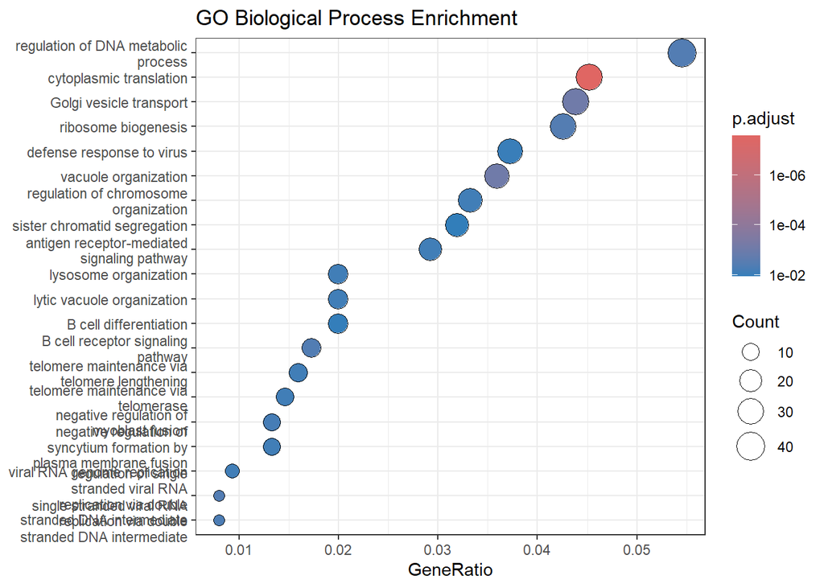

```r
# Extract significant probe IDs
sig_probe <- rownames(sig_genes)

# Map probes to gene symbols using the GPL annotation
gene_assignment <- gpl_table$gene_assignment[
  match(sig_probe, gpl_table$ID)
]

# Extract gene symbols
gene_symbols <- sapply(
  strsplit(gene_assignment, "///"),
  function(x) {
    if (length(x) == 0 || x[1] == "---") return(NA)

    parts <- trimws(strsplit(x[1], "//", fixed = TRUE)[[1]])

    if (length(parts) >= 2) parts[2] else NA
  }
)

gene_symbols <- unique(na.omit(gene_symbols))

# Convert gene symbols to Entrez IDs
gene_ids <- bitr(
  gene_symbols,
  fromType = "SYMBOL",
  toType = "ENTREZID",
  OrgDb = org.Hs.eg.db
)
# GO enrichment
ego <- enrichGO(
  gene = gene_ids$ENTREZID,
  OrgDb = org.Hs.eg.db,
  keyType = "ENTREZID",
  ont = "BP",
  pAdjustMethod = "BH",
  readable = TRUE
)

go_plot <- dotplot(ego, showCategory = 20) +
  theme_bw() +
  labs(
    title = "GO Biological Process Enrichment"
  )

go_plot
```

```r
ggsave(
  "results/GO_dotplot_MM_vs_NPC.png",
  plot = go_plot,
  width = 9,
  height = 7,
  dpi = 300,
  create.dir = TRUE
)
```

## 10. KEGG pathway enrichment

KEGG enrichment was used to identify biological pathways represented among the differentially expressed genes.

```r
ekegg <- enrichKEGG(
  gene = gene_ids$ENTREZID,
  organism = "hsa",
  pAdjustMethod = "BH"
)
```

```
## Reading KEGG annotation online: "https://rest.kegg.jp/link/hsa/pathway"...
```

```
## Reading KEGG annotation online: "https://rest.kegg.jp/list/pathway/hsa"...
```

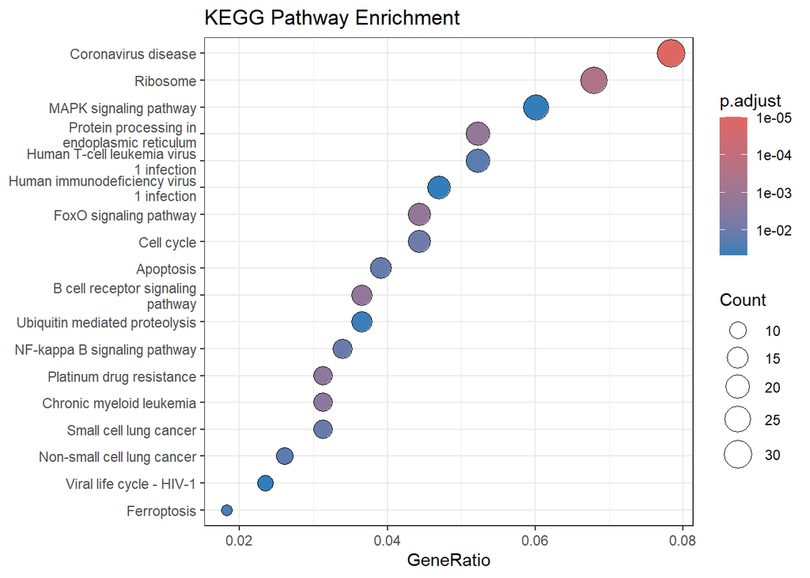

```r
kegg_plot <- dotplot(ekegg, showCategory = 20) +
  theme_bw() +
  labs(
    title = "KEGG Pathway Enrichment"
  )

kegg_plot
```

```r
ggsave(
  "results/KEGG_dotplot_MM_vs_NPC.png",
  plot = kegg_plot,
  width = 9,
  height = 7,
  dpi = 300,
  create.dir = TRUE
)
```

[figure not shown]

```r
library(cowplot)

combined_plot <- plot_grid(
  volcano_plot,
  pca_plot,
  go_plot,
  kegg_plot,
  ncol = 2,
  labels = c("A", "B", "C", "D")
)

combined_plot
```

```r
ggsave(
  "results/Combined_4_Plots.png",
  plot = combined_plot,
  width = 14,
  height = 12,
  dpi = 300,
  create.dir = TRUE
)
```

Methods

Dataset and Preprocessing

The GSE47552 gene expression dataset was obtained from the Gene Expression Omnibus (GEO) database. The expression data were processed and matched with the corresponding sample metadata. Samples were classified into multiple myeloma (MM) and normal plasma cell (NPC) groups for downstream analysis.

Principal Component Analysis

Principal component analysis (PCA) was performed on the processed gene expression data to examine overall variation among samples and assess the separation of the MM and NPC groups. The first two principal components were visualized using a scatter plot, with samples distinguished according to their experimental groups.

Differential Expression Analysis

Differential expression analysis was performed using the limma package in R. The MM and NPC groups were compared, and log fold-change (logFC), p-values, and adjusted p-values were calculated for each gene. The Benjamini–Hochberg method was used to control for multiple testing. Genes with an adjusted p-value below 0.05 were considered statistically significant, while an absolute logFC greater than 1 was used to identify genes with substantial expression changes.

Volcano Plot

Heatmap

A heatmap was generated using the selected significantly differentially expressed genes. The expression values were visualized across the analyzed samples, with samples annotated according to their experimental groups. A color palette from the RColorBrewer package was used to improve visualization of expression patterns.

Gene Ontology Enrichment Analysis

KEGG Pathway Analysis

KEGG pathway enrichment analysis was performed to identify biological pathways associated with the differentially expressed genes. The enriched pathways were examined and visualized to provide insight into the molecular processes potentially associated with the disease-related expression differences.

Multi-panel Visualization

Four selected plots were combined into a single multi-panel figure using the “plot_grid()” function from the cowplot package. The combined figure was formatted to provide a clear presentation of the major analytical results.